# Coverage maps for DGL2

This document details working with aligned RNAseq data to create coverage maps for DLG2.

## Setting up the environment

These are packages you will need for this notebook. For exact versions used, please refer to the session info at the bottom of this notebook.

```r
##########################################################################################
library('tidyverse')
library('ggplot2')
library('RColorBrewer')
library('Rsamtools')
library('rtracklayer')
library('GenomicAlignments')
library('bamsignals')
```

I want to set a base directory that we can use as a link to the directory where we will do most of the work. I use two directories here because the Workspace is what is pushed to GitHub and contains scripts and plot files, but the Repository is where more of the big data is stored that does not get pushed.

```r
##########################################################################################
generalDatasets = 'C:/Users/chughes/Documents/bccrc/projectsRepository/generalDatasets'
baseWorkspace = 'C:/Users/chughes/Documents/bccrc/projectsWorkspace/sorensenLab/relatedToDlg2'
baseRepository = 'C:/Users/chughes/Documents/bccrc/projectsRepository/sorensenLab/relatedToDlg2'
#generalDatasets = 'C:/Users/chris/OneDrive/Documents/bccrc/projectsRepository/generalDatasets'
#baseWorkspace = 'C:/Users/chris/OneDrive/Documents/bccrc/projectsWorkspace/sorensenLab/relatedToYbx1'
#baseRepository = 'C:/Users/chris/OneDrive/Documents/bccrc/projectsRepository/sorensenLab/relatedToYbx1'
```

## Data processing

First I extract the genomic range of all annotated exons for DLG2 from the hg38 GTF file we used in alignment. I then save this object for later use.

```r
##########################################################################################
gtf = rtracklayer::import('C:/Users/chughes/Documents/bccrc/databases/hg38/gencode_gtf/hg38.gtf')
dlg2Gtf = as.data.frame(gtf) %>%
  filter(grepl('DLG2', gene_name) & grepl('exon', type) & grepl('protein_coding', transcript_type))
saveRDS(dlg2Gtf, paste(baseRepository, '/sequencing20201217_ccleSequencingDataReprocessing/dlg2GtfAllExons.rds', sep = ''))
```

Read in the previous created GTF file and process the exon data to create a non-redudant set of exons.

```r
##########################################################################################
exonRangesRaw = readRDS(paste(baseRepository, '/sequencing20201217_ccleSequencingDataReprocessing/dlg2GtfAllExons.rds', sep = ''))
exonRangesGr = GRanges(exonRangesRaw)
exonRangesCollapse = as.data.frame(reduce(exonRangesGr)) %>%
  mutate(name = 'DLG2') %>%
  dplyr::select(seqnames, start, end, name, strand)
write.table(exonRangesCollapse, paste(baseRepository, '/sequencing20201217_ccleSequencingDataReprocessing/dlg2GtfCollapsedExons.bed', sep = ''),
            quote = FALSE, col.names = FALSE, row.names = FALSE, sep = '\t')
```

Using this bed regions file, I ran mosdepth on the regions as described elsewhere in this folder, and I will read these data in now and process them for plotting purposes.

```r
##########################################################################################
##this function goes through the provided coverage files
##and outputs a parsed object
#######################################################################
combineMosdepthFiles = function(filePath, ...){
  mosdepthData = read_tsv(filePath, col_names = c('seqname', 'start', 'end', 'symbol', 'coverage')) %>%
    mutate('accession' = sub('.*mosdepthAnalysis\\/(.*)\\.regions\\.bed\\.gz', '\\1', filePath)) %>%
    mutate('exon' = seq(43,1,-1)) %>%
    mutate('relativeCoverage' = coverage / max(coverage))
  print(paste('Processing file for fraction ', sub('.*mosdepthAnalysis\\/(.*)\\.regions\\.bed\\.gz', '\\1', filePath), '.', sep = ''))
  ##
  return(mosdepthData)
}

##get the list of input files
filePath = list.files(paste(baseRepository, '/sequencing20201217_ccleSequencingDataReprocessing/mosdepthAnalysis/', sep = ''),
                      pattern = '.regions.bed.gz$', full.names = TRUE)
##now proces the data and combine into a single set
coverageSet = do.call('rbind', lapply(filePath, combineMosdepthFiles))
```

```
[1] "Processing file for fraction SRR8615273."
```

```
[1] "Processing file for fraction SRR8615497."
```

```
[1] "Processing file for fraction SRR8615499."
```

```
[1] "Processing file for fraction SRR8615521."
```

```
[1] "Processing file for fraction SRR8615592."
```

```
[1] "Processing file for fraction SRR8615679."
```

```
[1] "Processing file for fraction SRR8615832."
```

```
[1] "Processing file for fraction SRR8615859."
```

```
[1] "Processing file for fraction SRR8616012."
```

```
[1] "Processing file for fraction SRR8616213."
```

```
[1] "Processing file for fraction SRR8616214."
```

Now we are ready to make some plots. I think best is probably a boxplot, so let’s try it out.

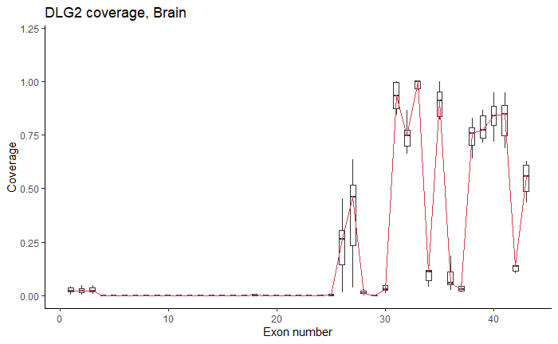

```r
##########################################################################################
coverageSummary = coverageSet %>%
  group_by(exon) %>%
  summarise(mean.cov = median(relativeCoverage, na.rm = TRUE),
            sd.cov = sd(relativeCoverage, na.rm = TRUE),
            n.cov = n())
##
ggplot(coverageSet, aes(exon, relativeCoverage, group = exon)) +
  geom_boxplot(size = 0.5, width = 0.5, outlier.shape = NA) +
  geom_point(data = coverageSummary, aes(exon, mean.cov, group = 1), color = brewer.pal(6,'Spectral')[1], size = 0.5) +
  geom_path(data = coverageSummary, aes(exon, mean.cov, group = 1), color = brewer.pal(6,'Spectral')[1], size = 0.5) +
  scale_y_continuous(limits = c(0,1.2), breaks = seq(0,2,0.25)) +
  labs(x = 'Exon number', y = 'Coverage', title = 'DLG2 coverage, Brain') +
  theme_classic()
ggsave(paste(baseRepository, '/sequencing20201217_ccleSequencingDataReprocessing/mosdepthAnalysis/boxplot_dlg2CoverageEwingRna.pdf', sep = ''),
         height = 4, width = 4, useDingbats = FALSE)
```

This might look better as a line plot?

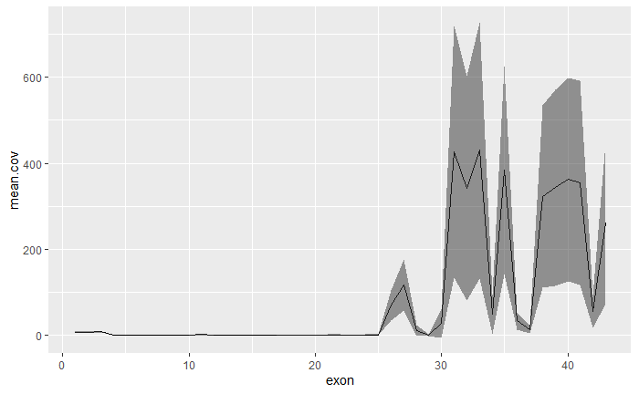

```r
##########################################################################################
test = coverageSet %>%
  group_by(exon) %>%
  summarise(mean.cov = mean(coverage, na.rm = TRUE),
            sd.cov = sd(coverage, na.rm = TRUE),
            n.cov = n()) %>%
  mutate(se.cov = sd.cov / sqrt(n.cov),
         lower.ci.cov = mean.cov - qt(1 - (0.05 / 2), n.cov - 1) * se.cov,
         upper.ci.cov = mean.cov + qt(1 - (0.05 / 2), n.cov - 1) * se.cov)
ggplot(test, aes(exon, mean.cov)) +
  geom_path() +
  geom_ribbon(aes(ymin = lower.ci.cov, ymax = upper.ci.cov), linetype = 2, alpha = 0.5)
```

Repeat this for the SCLC data.

```r
##########################################################################################
##this function goes through the provided coverage files
##and outputs a parsed object
#######################################################################
combineMosdepthFiles = function(filePath, ...){
  mosdepthData = read_tsv(filePath, col_names = c('seqname', 'start', 'end', 'symbol', 'coverage')) %>%
    mutate('accession' = sub('.*mosdepthAnalysis\\/(.*)\\.regions\\.bed\\.gz', '\\1', filePath)) %>%
    mutate('exon' = seq(43,1,-1)) %>%
    mutate('relativeCoverage' = coverage / max(coverage))
  print(paste('Processing file for fraction ', sub('.*mosdepthAnalysis\\/(.*)\\.regions\\.bed\\.gz', '\\1', filePath), '.', sep = ''))
  ##
  return(mosdepthData)
}

##get the list of input files
filePath = list.files(paste(baseRepository, '/sequencing20201217_ccleSequencingDataReprocessing/sclcLines/mosdepthAnalysis/', sep = ''),
                      pattern = '.regions.bed.gz$', full.names = TRUE)
##now proces the data and combine into a single set
coverageSet = do.call('rbind', lapply(filePath, combineMosdepthFiles))
```

```
[1] "Processing file for fraction SRR8615341."
```

```
[1] "Processing file for fraction SRR8615423."
```

```
[1] "Processing file for fraction SRR8616112."
```

```
[1] "Processing file for fraction SRR8616152."
```

```
[1] "Processing file for fraction SRR8616161."
```

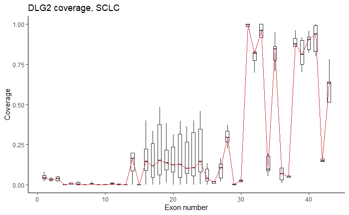

```r
##########################################################################################
coverageSummary = coverageSet %>%
  group_by(exon) %>%
  summarise(mean.cov = median(relativeCoverage, na.rm = TRUE),
            sd.cov = sd(relativeCoverage, na.rm = TRUE),
            n.cov = n())
##
ggplot(coverageSet, aes(exon, relativeCoverage, group = exon)) +
  geom_boxplot(size = 0.5, width = 0.5, outlier.shape = NA) +
  geom_point(data = coverageSummary, aes(exon, mean.cov, group = 1), color = brewer.pal(6,'Spectral')[1], size = 0.5) +
  geom_path(data = coverageSummary, aes(exon, mean.cov, group = 1), color = brewer.pal(6,'Spectral')[1], size = 0.5) +
  #scale_y_continuous(limits = c(0,1.2), breaks = seq(0,2,0.25)) +
  labs(x = 'Exon number', y = 'Coverage', title = 'DLG2 coverage, SCLC') +
  theme_classic()
ggsave(paste(baseRepository, '/sequencing20201217_ccleSequencingDataReprocessing/sclcLines/mosdepthAnalysis/boxplot_dlg2CoverageSclcRna.pdf', sep = ''),
         height = 4, width = 4, useDingbats = FALSE)
```

[session information not shown]